# R Notebook

Load the required packages

```r
suppressMessages(library("knitr"))
suppressMessages(library("MOFA2"))
suppressMessages(library("MOFAdata"))
suppressMessages(library("data.table"))
suppressMessages(library("ggplot2"))
suppressMessages(library("tidyverse"))
suppressMessages(library("MultiAssayExperiment"))

suppressMessages(library("r.jive"))
suppressMessages(library("omicade4"))
suppressMessages(library("BloodCancerMultiOmics2017"))
suppressMessages(library("survival"))
suppressMessages(library("survminer"))
suppressMessages(library("zoo"))
suppressMessages(library("pheatmap"))
suppressMessages(library("fgsea", quietly = TRUE))
```

```r
source("../scripts/HelperForTheCourse.R")
```

Load the data

```r
#data("CLL_data", package = "MOFAdata")
#data("CLL_covariates", package = "MOFAdata")
utils::data("CLL_data")
lapply(CLL_data,dim)
```

```
$Drugs
[1] 310 200

$Methylation
[1] 4248  200

$mRNA
[1] 5000  200

$Mutations
[1]  69 200
```

Load the metadata

```r
CLL_covariates <- fread("http://ftp.ebi.ac.uk/pub/databases/mofa/cll_vignette/sample_metadata.txt")

head(CLL_covariates) %>% kable
```

[output not shown]

CLL_covariates has information about relevant patient meta-data such as IGHV status and trisomy-12 status.

## MOFA

Create MOFA object

```r
MOFAobject <- create_mofa(CLL_data)
```

```
Creating MOFA object from a list of matrices (features as rows, sample as columns)...
```

```r
MOFAobject
```

```
Untrained MOFA model with the following characteristics:
 Number of views: 4
 Views names: Drugs Methylation mRNA Mutations
 Number of features (per view): 310 4248 5000 69
 Number of groups: 1
 Groups names: group1
 Number of samples (per group): 200
```

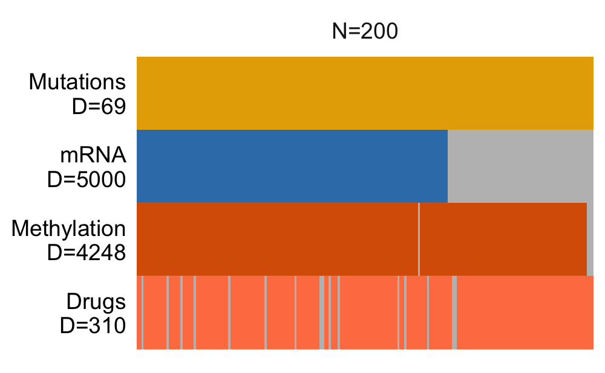

```r
plot_data_overview(MOFAobject)
```

Load pre-trained MOFA model

```r
#filepath <- system.file("extdata", "CLL_model.hdf5", package = "MOFAdata")
MOFAobject <- readRDS(url("http://ftp.ebi.ac.uk/pub/databases/mofa/cll_vignette/MOFA2_CLL.rds"))
```

```r
MOFAobject
```

```
Trained MOFA with the following characteristics:
 Number of views: 4
 Views names: Drugs Methylation mRNA Mutations
 Number of features (per view): 310 4248 5000 69
 Number of groups: 1
 Groups names: group1
 Number of samples (per group): 200
 Number of factors: 15
```

We limit the number of factors to 10 in all the subsequent analysis.

```r
numFactors = 10
```

Extract weights and factors matrix

```r
MOFAweights <- get_weights(MOFAobject)
```

```r
MOFAfactorsList <- get_factors(MOFAobject)
MOFAfactors <- MOFAfactorsList[["group1"]][, 1:numFactors]
colnames(MOFAfactors) <- paste0("LF", 1:numFactors)
```

## Impute the data

Replacing NAs with feature-wise mode in case of mutation data and feature-wise mean in case of other non-binary data

Or remove mutation data as imputing is too hard/dangerous

```r
#To make the comparisons with MOFA, fill in the missing values with feature-wise mean
#Participants can play around here with various imputation techniques
CLL_data_imputed <- list("Mutations" = t(apply(CLL_data[["Mutations"]], 1, function(x) {
  x[which(is.na(x))] <- calculateMode(x, na.rm = TRUE)
  return(x)})))
CLL_data_imputed[c("Drugs", "mRNA", "Methylation")] <- lapply(CLL_data[c("Drugs", "mRNA", "Methylation")], function(x) t(na.aggregate(t(x))))
```

# Note that the following sections are derived from the momix pipeline[https://github.com/ComputationalSystemsBiology/momix-notebook] made available by Laura et al. (2021)[https://doi.org/10.1038/s41467-020-20430-7]

## JIVE

```r
JIVEfactorization <- jive(CLL_data_imputed, rankJ=numFactors, rankA = rep(numFactors, length(CLL_data_imputed)), method = "given", conv = "default", maxiter = 100, showProgress=TRUE)
```

```
Running JIVE algorithm for ranks:
joint rank: 10 , individual ranks: 10 10 10 10
```

```r
rankJV <- JIVEfactorization$rankJ;
rankIV.v <- JIVEfactorization$rankA;
J <- numeric(0)
ng <- 0
JIVEweights <- list();
for(j in 1:length(CLL_data_imputed)){
  J <- rbind(J,JIVEfactorization$joint[[j]]);
  ng <- c(ng,dim(JIVEfactorization$joint[[j]])[1])
}
svd.o <- svd(J);
jV <- svd.o$v %*% diag(svd.o$d);
for(j in 1:length(CLL_data_imputed)){
  JIVEweights[[j]] <- svd.o$u[(1+sum(ng[1:j])):sum(ng[1:j+1]),1:rankJV]; ###error in dimension
  rownames(JIVEweights[[j]]) <- rownames(CLL_data_imputed[[j]])
  colnames(JIVEweights[[j]]) <- paste0("LF", 1:numFactors)
}
names(JIVEweights) <- names(CLL_data_imputed)
```

```r
JIVEfactors <- jV[,1:rankJV]
rownames(JIVEfactors) <- colnames(CLL_data_imputed[[1]])
colnames(JIVEfactors) <- paste0("LF", 1:numFactors)
```

## MCIA

```r
MCIAfactorization <- mcia(CLL_data_imputed, cia.nf = numFactors)
```

```r
MCIAfactors <- as.matrix(MCIAfactorization$mcoa$SynVar)
colnames(MCIAfactors) <- paste0("LF", 1:numFactors)
```

```r
MCIAweights <- list()
for(j in 1:length(CLL_data_imputed)){
    MCIAweights[[j]]<-as.matrix(MCIAfactorization$mcoa$axis[1:dim(CLL_data_imputed[[j]])[1],])
    rownames(MCIAweights[[j]])<-rownames(CLL_data_imputed[[j]])
    colnames(MCIAweights[[j]])<-paste0("LF", 1:numFactors)
}
names(MCIAweights) <- names(CLL_data_imputed)
```

## Compare the results

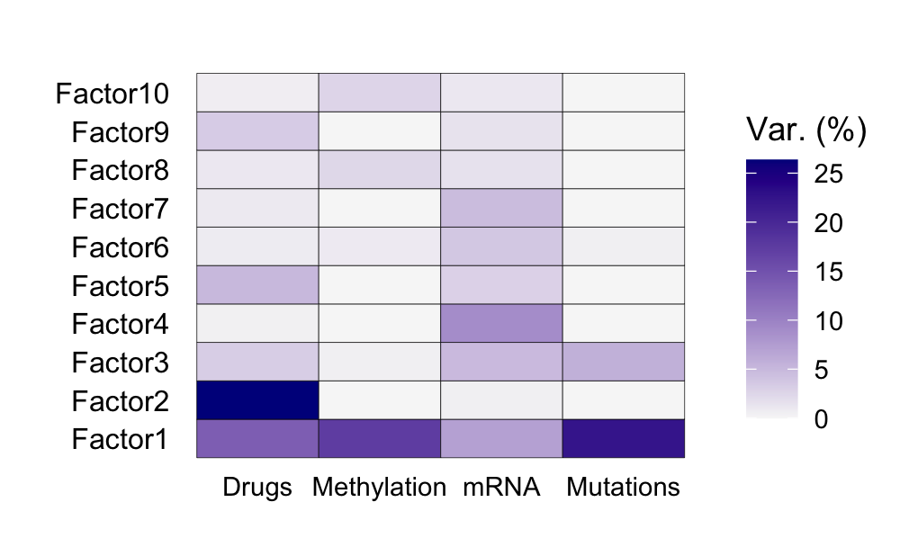

```r
plot_variance_explained(MOFAobject, factors = paste("Factor",1:numFactors, sep=""))
```

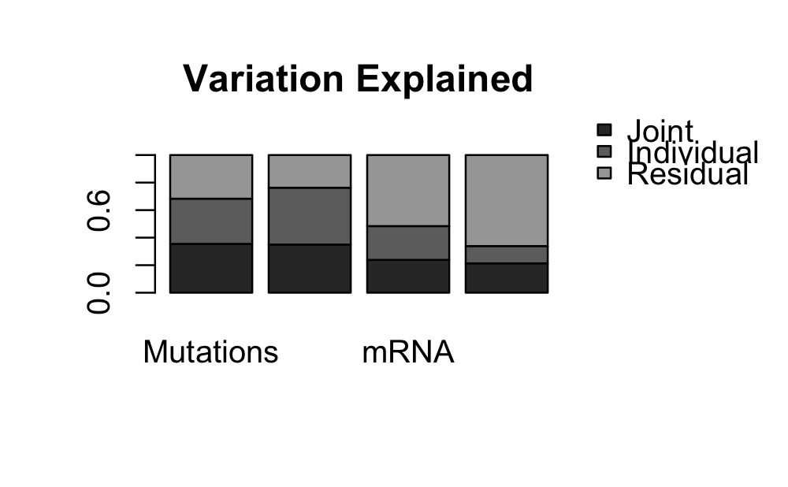

```r
plot(JIVEfactorization)
```

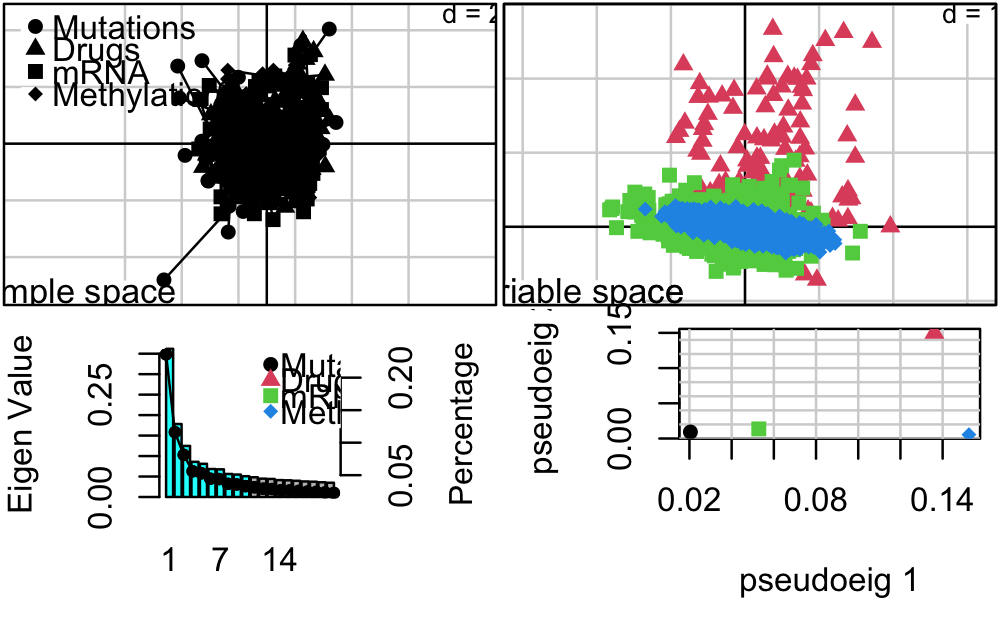

```r
plot(MCIAfactorization, axes = c(1,2), sample.lab = FALSE, df.color = 1:4)
```

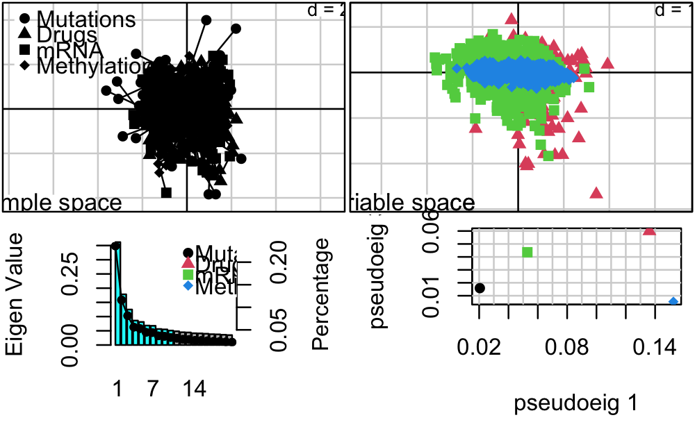

```r
plot(MCIAfactorization, axes = c(1,3), sample.lab = FALSE, df.color = 1:4)
```

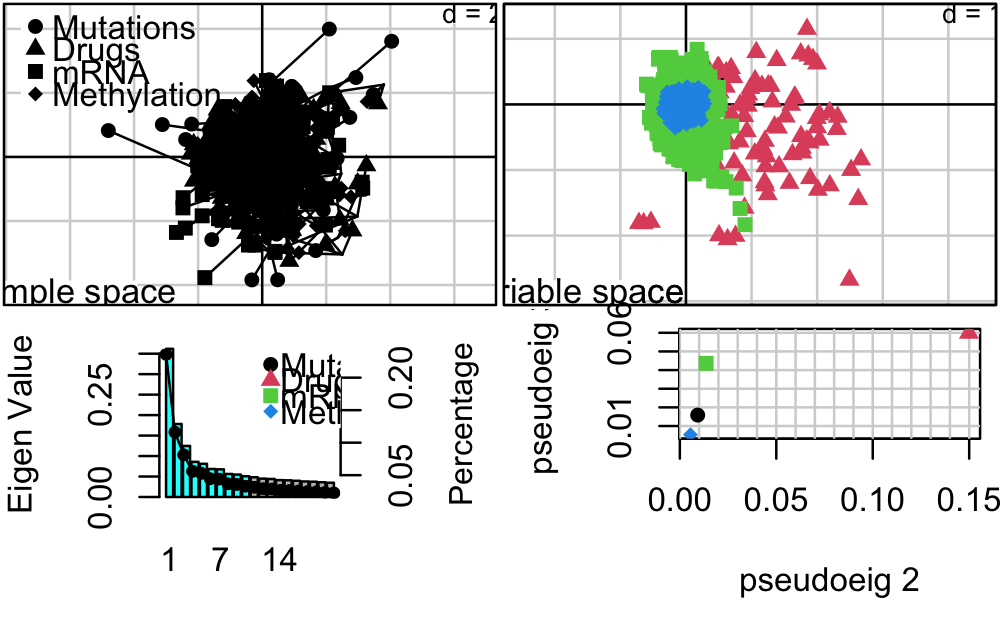

```r
plot(MCIAfactorization, axes = c(2,3), sample.lab = FALSE, df.color = 1:4)
```

In case of MOFA => Along with variance explained per view, variance explained per factor per view can also be visualized. In case of JiVE => Only variance explained per view can be visualized In case of MCIA => factors = PCs, sorted by their eigen-values as we have selected the first 10 eigenvectors for this analysis. The variance explained per factor per view is not available but overall the eigen-vectors are sorted by their eigenvalues.

## Benchmark 1: Clinical association with IGHV and trisomy 12

[figure not shown]

```r
library(pheatmap)
source("../scripts/HelperForTheCourse.R")
visualizeWeightsHeatmap(MOFAweights, 'Mutations')
```

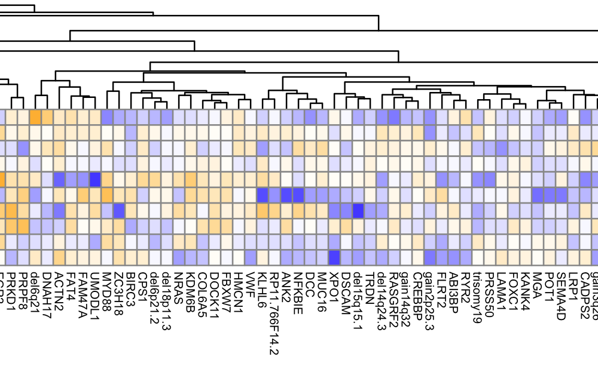

```r
visualizeWeightsHeatmap(JIVEweights, 'Mutations')
```

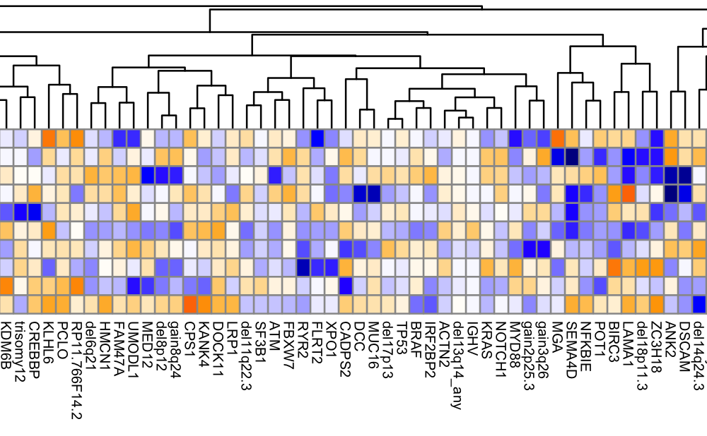

```r
visualizeWeightsHeatmap(MCIAweights, 'Mutations')
```

```r
metagenesList = list("MOFA" = MOFAweights,"MCIA" = MCIAweights, "JIVE" = JIVEweights)
```

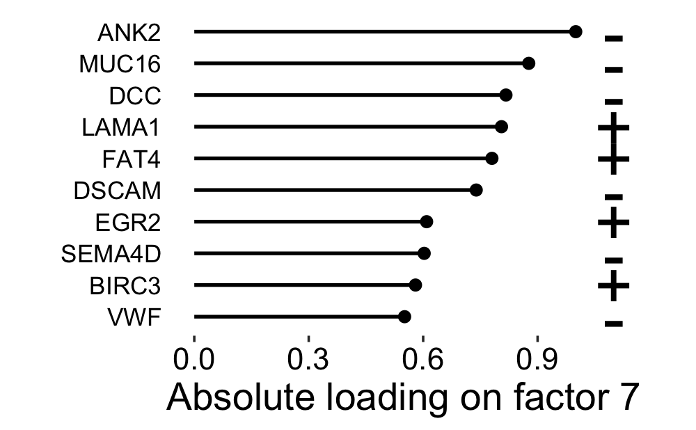

```r
source("../scripts/HelperForTheCourse.R")
plotTopWeightsUsingSeparateWeightsAndFactors(metagenesList[["MCIA"]], "Mutations", factor = 7, nfeatures = 10)
```

```r
data(lpdAll, patmeta, drugs, package = "BloodCancerMultiOmics2017")
```

```r
survT <- extractMetadata(lpdCLL, patmeta, drugs)
```

```r
factorsList = list("MOFA" = MOFAfactors,"MCIA" = MCIAfactors, "JIVE" = JIVEfactors)
factorsList = lapply(factorsList, function(g) {
  indices = match(rownames(survT), rownames(g))
  return(g[indices, ])
})
```

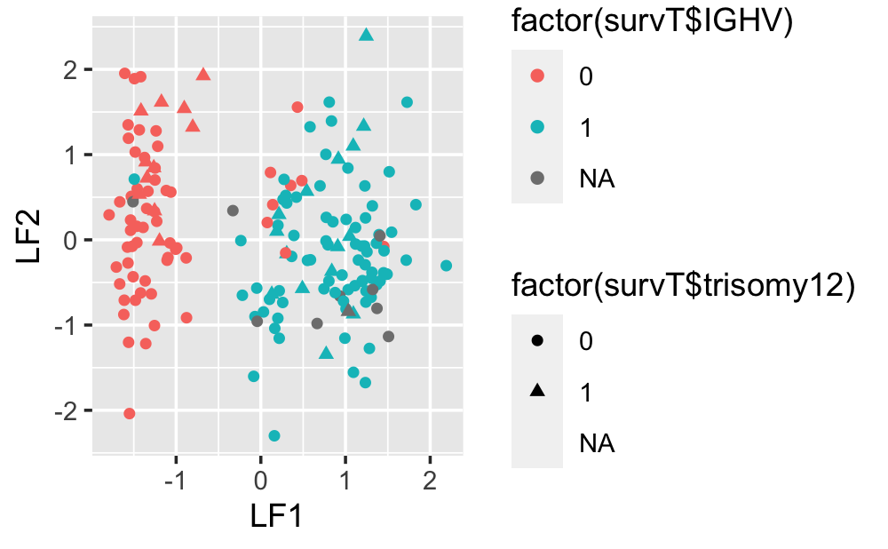

```r
ggplot(data.frame(MOFAfactors)[match(rownames(survT), rownames(MOFAfactors)), ], aes(x = LF1, y = LF2, colour = factor(survT$IGHV), shape = factor(survT$trisomy12))) +
  geom_point()
```

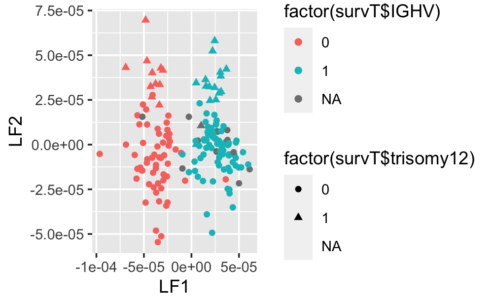

```r
ggplot(data.frame(JIVEfactors)[match(rownames(survT), rownames(JIVEfactors)), ], aes(x = LF1, y = LF2, colour = factor(survT$IGHV), shape = factor(survT$trisomy12))) +
  geom_point()
```

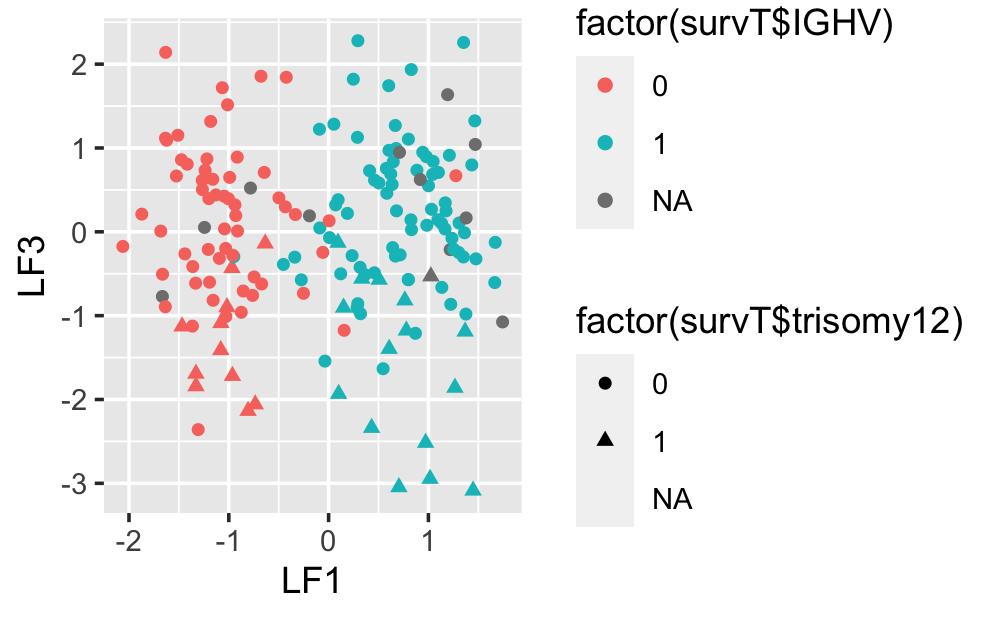

```r
ggplot(data.frame(MCIAfactors)[match(rownames(survT), rownames(MCIAfactors)), ], aes(x = LF1, y = LF3, colour = factor(survT$IGHV), shape = factor(survT$trisomy12))) +
  geom_point()
```

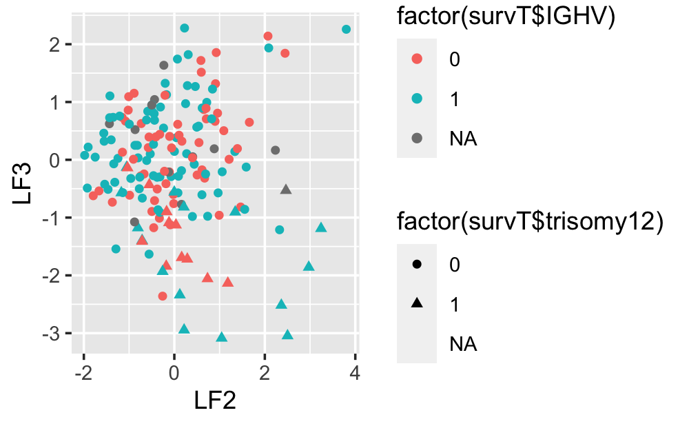

```r
ggplot(data.frame(MCIAfactors)[match(rownames(survT), rownames(MCIAfactors)), ], aes(x = LF2, y = LF3, colour = factor(survT$IGHV), shape = factor(survT$trisomy12))) +
  geom_point()
```

## Benchmark 2: Association with biological annotations

```r
source("../scripts/HelperForTheCourse.R")
data("reactomeGS")
pval.thr=0.05
#pathToGeneSymbols = "../data/GeneSymbols.tsv"
#databasePath <- "../data/c2.cp.reactome.v7.0.symbols.gmt" #REACTOME
#databasePath <- "../data/h.all.v7.0.symbols.gmt" #Hallmarks
#databasePath <- "../data/c5.all.v7.0.symbols.gmt" #GO
out_bio <- biologicalComparisonModifiedWithMofaCode(metagenesList, factorsList, CLL_data, pathToFseaScript = "../scripts/FSEA.R", database = reactomeGS, pval.thr=pval.thr)
```

```
Doing Feature Set Enrichment Analysis with the following options...
View: mRNA
Factors: LF1 LF2 LF3 LF4 LF5 LF6 LF7 LF8 LF9 LF10
Number of feature sets: 501
Local statistic: loading
Transformation: abs.value
Global statistic: mean.diff
Statistical test: parametric
```

```r
out_bio
```

|  | selectivity | nonZeroFacs | total_pathways |
| --- | --- | --- | --- |
| MOFA | 0.3910506 | 6 | 195 |
| MCIA | 0.5000000 | 2 | 5 |
| JIVE | 0.3370370 | 7 | 84 |

```r
#tiff("BioEnr_go_fig1.tiff", units="in", width=8.95, height=6.05, res=300)
biological_analysis <- data.frame(
    matrix(data = NA, ncol=4, nrow=0,
           dimnames = list(c(), c("methods", "selectivity", "nonZeroFacs", "total_pathways"))
          ),
    stringsAsFactors = FALSE)
biological_analysis <- rbind(biological_analysis,
                                data.frame(methods=rownames(out_bio), out_bio))

min_nonZero = min(biological_analysis[, "nonZeroFacs"])
max_nonZero = max(biological_analysis[, "nonZeroFacs"])
g <- ggplot(biological_analysis,
            aes(x=nonZeroFacs,y=selectivity)) +
    geom_point(aes(colour = methods), size=5, alpha=.6, position=position_jitter(h=0, w=0.15))+
    theme_bw() +
    scale_shape_manual(values=c(15,17,16)) +
    scale_color_manual(values=c('#FF00FF', '#FF6E28', '#C8961E', '#FF0000', '#0000FF', '#A0A0A0', '#48D1CC', '#00FF00')) +
    #ylim(floor(min((biological_analysis[,"selectivity"]*10)-.4)) / 10,
    #     ceiling(max((biological_analysis[,"selectivity"]*10)+.2)) / 10) +
    labs(title="Biological annotations",
         x="# metagenes (factors) enriched in at least one annotation") +
    theme(plot.title = element_text(size=14,face="bold"),
          axis.text = element_text(size=11),
          axis.title = element_text(size=13),
          legend.text=element_text(size=10)) +
    ylab("Selectivity") +
    ylim(c(0, 1))+
    labs(colour = "Methods", shape = "Cancer") +
    guides(color = guide_legend(order = 1),size = guide_legend(order = 3)) +
    #scale_x_discrete() + scale_x_discrete(limits=min_nonZero:max_nonZero) +
    scale_x_discrete(limits=min_nonZero:max_nonZero, labels = c(min_nonZero:max_nonZero));
```

```
Continuous limits supplied to discrete scale.
Did you mean `limits = factor(...)` or `scale_*_continuous()`?
```

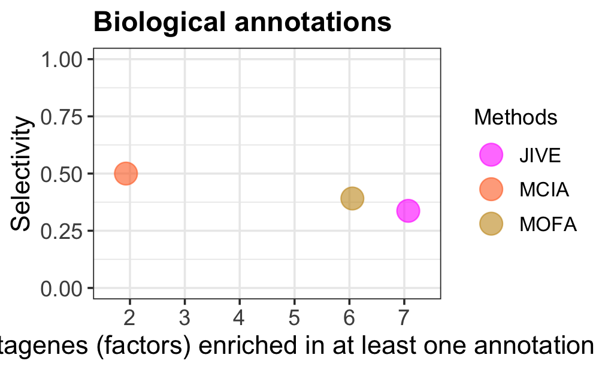

```r
g
```

```r
#dev.off()
```

```r
source("../scripts/FSEA.R")
data("reactomeGS")
gseaResults = list()
for (methodName in names(metagenesList)){
  gseaResults[[methodName]] <- runEnrichmentAnalysisUsingSeparateWeightsAndFactors(
    metagenesList[[methodName]], factorsList[[methodName]], CLL_data,
    view = "mRNA",
    feature.sets = reactomeGS,
    alpha = pval.thr)

  #plotEnrichmentBars(gsea, alpha=pval.thr)

}
```

```
Doing Feature Set Enrichment Analysis with the following options...
View: mRNA
Factors: LF1 LF2 LF3 LF4 LF5 LF6 LF7 LF8 LF9 LF10
Number of feature sets: 501
Local statistic: loading
Transformation: abs.value
Global statistic: mean.diff
Statistical test: parametric
Doing Feature Set Enrichment Analysis with the following options...
View: mRNA
Factors: LF1 LF2 LF3 LF4 LF5 LF6 LF7 LF8 LF9 LF10
Number of feature sets: 501
Local statistic: loading
Transformation: abs.value
Global statistic: mean.diff
Statistical test: parametric
Doing Feature Set Enrichment Analysis with the following options...
View: mRNA
Factors: LF1 LF2 LF3 LF4 LF5 LF6 LF7 LF8 LF9 LF10
Number of feature sets: 501
Local statistic: loading
Transformation: abs.value
Global statistic: mean.diff
Statistical test: parametric
```

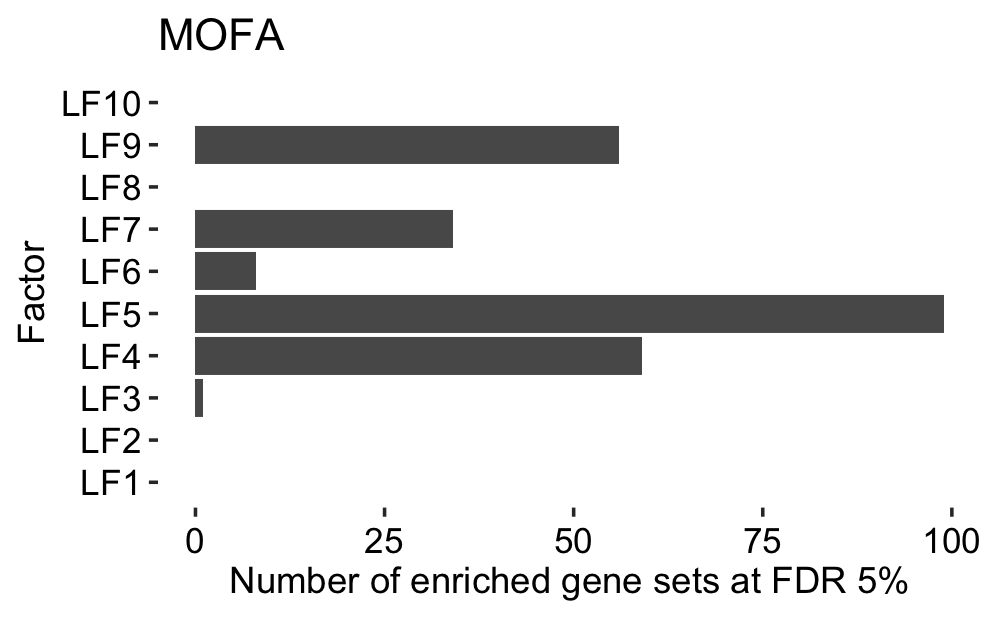

```r
# heatmap of enriched pathways per factor at 1% FDR
# plotEnrichmentHeatmap(gsea, alpha=pval.thr)
# plot number of enriched pathways per factor at 1% FDR
plotEnrichmentBars(gseaResults[["MOFA"]], alpha=pval.thr, methodName = "MOFA")
```

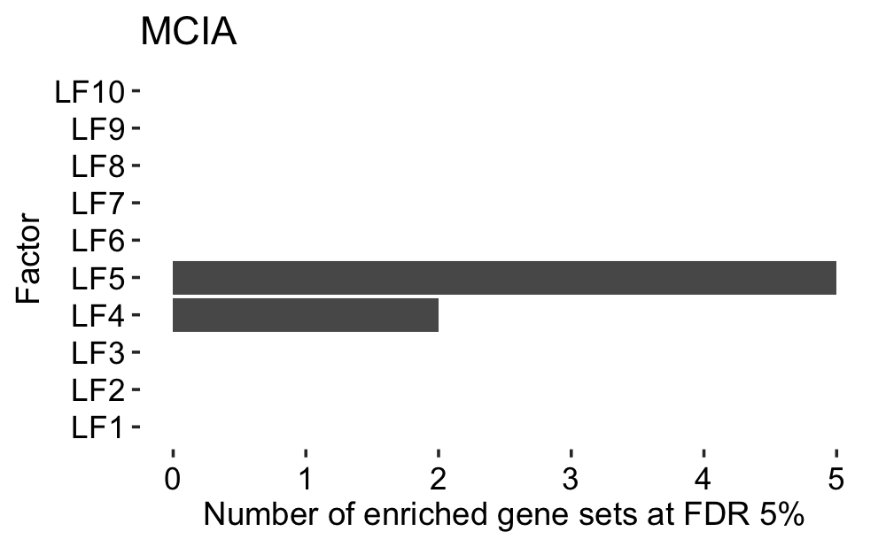

```r
plotEnrichmentBars(gseaResults[["MCIA"]], alpha=pval.thr, methodName = "MCIA")
```

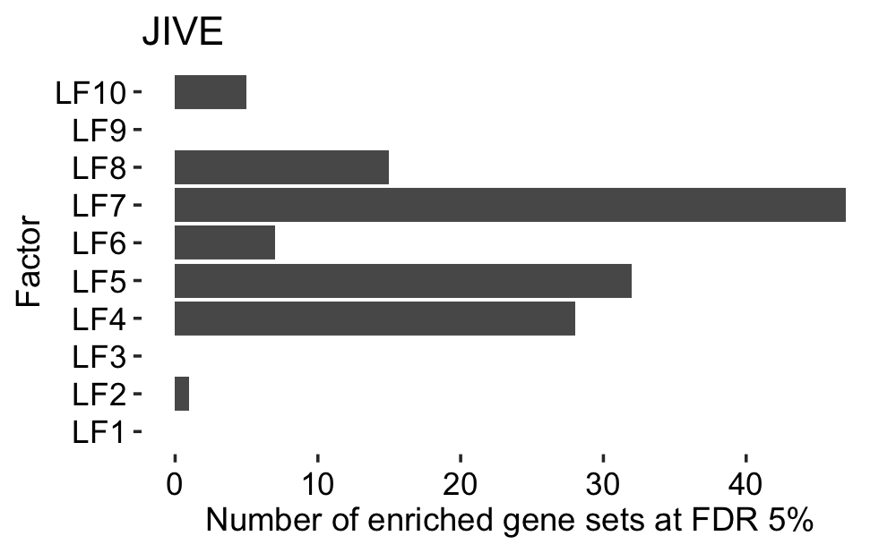

```r
plotEnrichmentBars(gseaResults[["JIVE"]], alpha=pval.thr, methodName = "JIVE")
```

[figure not shown]

```r
source("../scripts/FSEA.R")
interestingFactors <- 4:5

fseaplots <- lapply(interestingFactors, function(factor) {
  plotEnrichmentUsingSeparateWeightsAndFactors(
    gseaResults[["MOFA"]],
    factor = factor,
    alpha = pval.thr, methodName = "MOFA",
    max.pathways = 10 # The top number of pathways to display
  )
})

cowplot::plot_grid(fseaplots[[1]], fseaplots[[2]],
                   ncol = 1, labels = paste("Factor", interestingFactors))
```

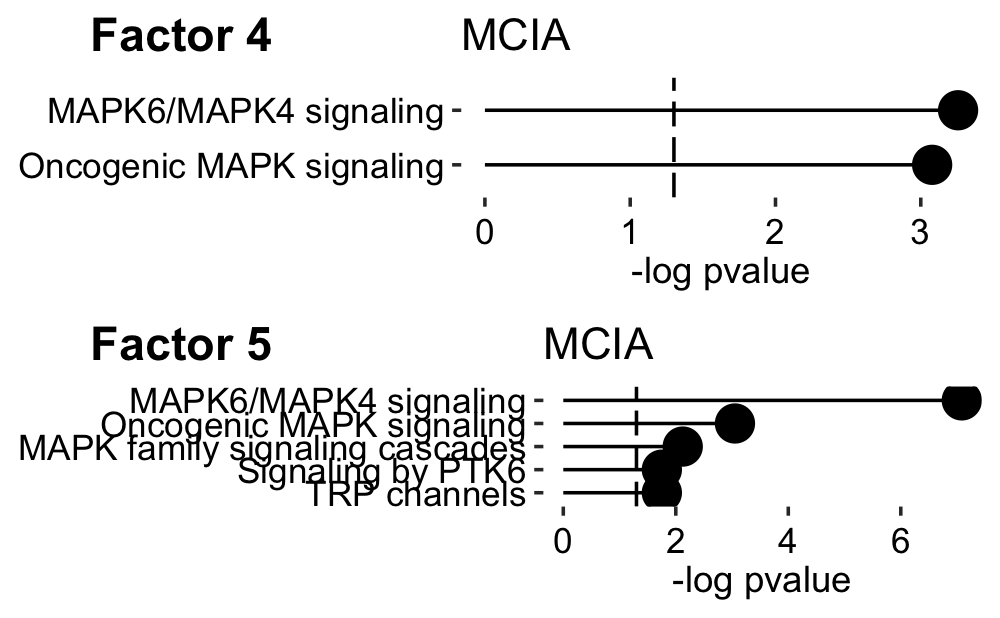

```r
fseaplots <- lapply(interestingFactors, function(factor) {
  plotEnrichmentUsingSeparateWeightsAndFactors(
    gseaResults[["MCIA"]],
    factor = factor,
    alpha = pval.thr, methodName = "MCIA",
    max.pathways = 10 # The top number of pathways to display
  )
})

cowplot::plot_grid(fseaplots[[1]], fseaplots[[2]],
                   ncol = 1, labels = paste("Factor", interestingFactors))
```

[figure not shown]

```r
interestingFactors <- c(5, 7)
fseaplots <- lapply(interestingFactors, function(factor) {
  plotEnrichmentUsingSeparateWeightsAndFactors(
    gseaResults[["JIVE"]],
    factor = factor,
    alpha = pval.thr, methodName = "JIVE",
    max.pathways = 10 # The top number of pathways to display
  )
})

cowplot::plot_grid(fseaplots[[1]], fseaplots[[2]],
                   ncol = 1, labels = paste("Factor", interestingFactors))
```